# Project

# תקציר

# מבוא

פרסומות הסופרבול התעלו מעבר לאופי המסחרי שלהן והפכו לאבני בוחן תרבותיות שמושכות מיליוני צופים ברחבי העולם. הפרסומות הללו, שמוצגות במהלך משחק האליפות של ליגת הפוטבול הלאומית, הן חלק מרכזי בתרבות המשחקים האלו. לא רק שהם ידועות בערכן הבידורי ובכוכבים המפורסמים שמשתתפים בהן, אלא שהן גם מעוררות שיחות, יוצרות באזז ומשאירות רושם מתמשך על החברה. אין להכחיש את ההשפעה התרבותית של פרסומות אלו, שכן הן מגיעות לקהל של למעלה מ-100 מיליון צופים מדי שנה, מה שהופך את הסופרבול לאחד מאירועי הטלוויזיה הנצפים ביותר בעולם. הפרסומות הללו הפכו לסמל של צרכנות אמריקאית, יצירתיות ומצוינות פרסומית. רמת העניין ותשומת הלב שאנשים מקדישים לפרסומות המחצית היא יוצאת דופן. הפרסומות הפכו לחלק בלתי נפרד מחוויית הסופרבול. במחקר שנעשה נמצא כי 70 אחוז מהצופים מצפים לפרסומות וכי כמעט אחד מכל ארבעה צופים במשחק במיוחד עבור הפרסומות, ורואים בהן סוג של בידור בדומה למשחק עצמו. פיתוי החברות לפרסם פרסומות שכאלו גובה מחיר משמעותי. מפרסמים מוכנים להשקיע סכומי כסף מופקעים כדי להבטיח מקום במהלך משבצת הזמן הנחשקת הזו, בהתחשב בכמות הצפייה העצומה וההשפעה התרבותית. המחיר של מודעות אלו ממשיך לעלות, כאשר העלות הממוצעת למיקום של 30 שניות במהלך הסופרבול הגיעה לשבעה מיליון דולר בשנים האחרונות. למרות המחיר הגבוה, המחקרים שנעשו עד היום לרוב מצביעים על כך שהפרסומות מייצרות תשואה חיובית ומשפיעות מאוד על פופלאריות החברה המפרסמת. בפרויקט זה, נחקור את הערך הכספי של מודעות אלו, ונבחון את הויראליות שנוצרת בעקבות הפרסומות הללו. על ידי בחינת עלות הפרסומות, אנו שואפים לענות על שתי שאלות מרכזיות:

1. האם קיימת התאמה בין מחירן של הפרסומות לבין הויראליות שנוצרת בעקבותן.
2. האם קיימת התאמה בין מחירן של הפרסומות לבין הויראליות שנוצרת בעקבותן.

# שיטות

# תוצאות

```r
fmt <- "%Y-%m-%d"

data <- get_data() # the main dataset, contains ads info
rating <- get_rating_data() # contains rating info, e.g., ads cost, viewrs and etc
general <- get_general_data() # ads categories, e.g., beer, car and etc
df <- read.csv("data\\trends_data.csv")
```

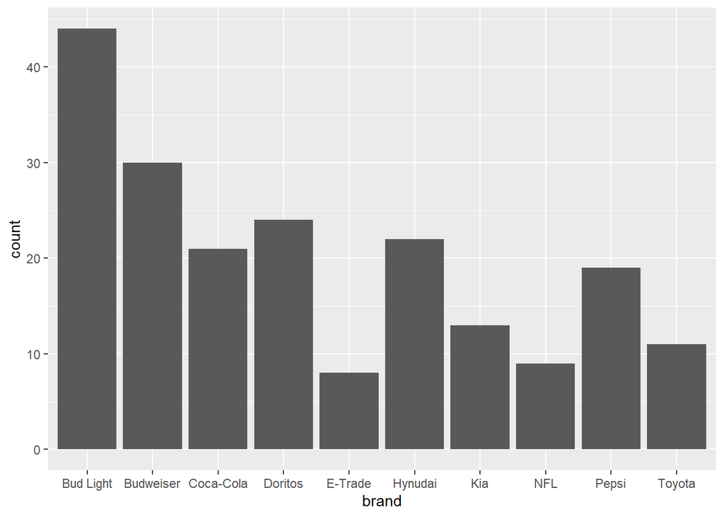

```r
brands = unique(data['brand'])
brand_q <- data %>%
  group_by(brand) %>%
  summarise(count = n())

ggplot(data=brand_q, aes(x=brand, y=count))+
  geom_bar(stat = 'identity')
```

```r
brand <-  "Doritos"
dates <-  search_dates(brand)
```

בדיקה על מותג מסוים בכל שנות הסופרבול

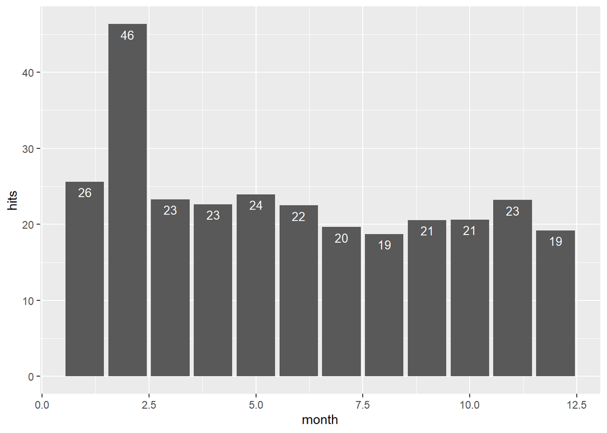

```r
by_month <- gtopics("Doritos","all") %>%
  group_by(month=month(date)) %>%
  summarise(hits=mean(hits))

ggplot(by_month, aes(x=month,y=hits)) +
  geom_bar(stat="identity", position=position_dodge())+
 geom_text(aes(label=round(hits)), vjust=1.6, color="white",
            position = position_dodge(0.9), size=3.5)
```

```r
#for (brand in brands$brand) {df <- update_df(df, brand); Sys.sleep(6)}
#df$date <- as.Date(df$date)
```

```r
head(df)
```

```
##   X       date  brand hits is_sup_week is_sup_year
## 1 1 2004-01-04 Toyota   82       FALSE        TRUE
## 2 2 2004-01-11 Toyota   84       FALSE        TRUE
## 3 3 2004-01-18 Toyota   88       FALSE        TRUE
## 4 4 2004-01-25 Toyota   81       FALSE        TRUE
## 5 5 2004-02-01 Toyota   75        TRUE        TRUE
## 6 6 2004-02-08 Toyota   74       FALSE        TRUE
```

```r
by_week <- df %>%
  group_by(is_sup_week, brand) %>%
  summarise(hits=mean(hits))
by_week
```

```
## # A tibble: 20 × 3
## # Groups:   is_sup_week [2]
##    is_sup_week brand       hits
##    <lgl>       <chr>      <dbl>
##  1 FALSE       Bud Light  43.6
##  2 FALSE       Budweiser  30.8
##  3 FALSE       Coca-Cola  70.5
##  4 FALSE       Doritos    26.0
##  5 FALSE       E-Trade     9.75
##  6 FALSE       Hynudai    81.0
##  7 FALSE       Kia        77.5
##  8 FALSE       NFL        42.7
##  9 FALSE       Pepsi      58.4
## 10 FALSE       Toyota     81.7
## 11 TRUE        Bud Light  97.3
## 12 TRUE        Budweiser  99.4
## 13 TRUE        Coca-Cola  77.6
## 14 TRUE        Doritos   100
## 15 TRUE        E-Trade     0
## 16 TRUE        Hynudai    91.2
## 17 TRUE        Kia        92.4
## 18 TRUE        NFL        33.2
## 19 TRUE        Pepsi      90.8
## 20 TRUE        Toyota     85
```

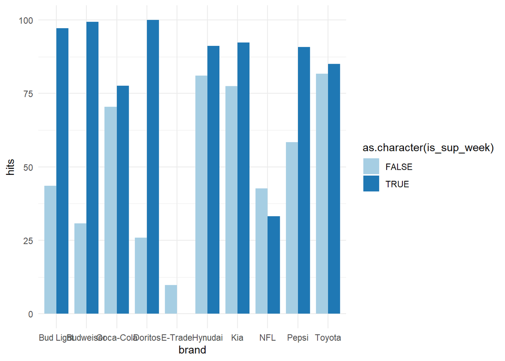

```r
ggplot(data=by_week, aes(x=brand, y=hits, fill=as.character(is_sup_week), width=0.8)) +
  geom_bar(stat="identity", position=position_dodge())+
  scale_fill_brewer(palette="Paired")+
  theme_minimal()
```

not sure about this one (delete ? )

```r
by_month <- df %>%
  group_by(brand, m=(month(date) == 2) & is_sup_year ) %>%
  summarise(hits=mean(hits))
by_month
```

```
## # A tibble: 20 × 3
## # Groups:   brand [10]
##    brand     m      hits
##    <chr>     <lgl> <dbl>
##  1 Bud Light FALSE 44.0
##  2 Bud Light TRUE  51.4
##  3 Budweiser FALSE 30.8
##  4 Budweiser TRUE  47.4
##  5 Coca-Cola FALSE 70.7
##  6 Coca-Cola TRUE  69.0
##  7 Doritos   FALSE 26.1
##  8 Doritos   TRUE  41.6
##  9 E-Trade   FALSE  9.90
## 10 E-Trade   TRUE   1.83
## 11 Hynudai   FALSE 81.0
## 12 Hynudai   TRUE  85.0
## 13 Kia       FALSE 77.2
## 14 Kia       TRUE  87.3
## 15 NFL       FALSE 43.5
## 16 NFL       TRUE  18.1
## 17 Pepsi     FALSE 58.1
## 18 Pepsi     TRUE  72.2
## 19 Toyota    FALSE 81.6
## 20 Toyota    TRUE  86.2
```

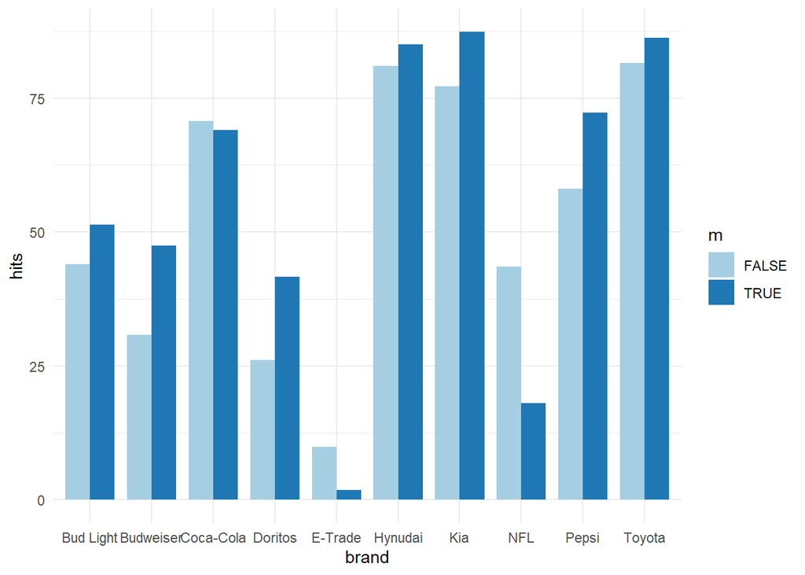

```r
ggplot(data=by_month, aes(x=brand, y=hits, fill=m, width=0.8)) +
  geom_bar(stat="identity", position=position_dodge())+
  scale_fill_brewer(palette="Paired")+
  theme_minimal()
```

```r
samp_dates=sample(seq(as.Date('2016/04/07'), as.Date('2016/12/28'), by="day"), 30)
brand="Pepsi"
df <- tibble(year=c(as.numeric(NA)), days=c(as.character(NA)), hits=c(as.numeric(NA))) %>% na.omit()

for (i in seq(length(samp_dates)))
{
  output <- gtopics_r(brand, date=samp_dates[i], rday=2)

  temp <- tibble(year=2016,
                                     days='samp',
                                     hits=mean(output$hits))
  df <- df %>% add_row(temp)
}
df
```

```
## # A tibble: 30 × 3
##     year days   hits
##    <dbl> <chr> <dbl>
##  1  2016 samp   86
##  2  2016 samp   95.4
##  3  2016 samp   91.2
##  4  2016 samp   91.6
##  5  2016 samp   92
##  6  2016 samp   95
##  7  2016 samp   91.8
##  8  2016 samp   88.4
##  9  2016 samp   95.8
## 10  2016 samp   88
## # ℹ 20 more rows
```

```r
ads_cost <- sapply(data$year,
               function (y) {
                 return(filter(rating,year==y)$cost_of_30_second_ad_usd)
               })

data <- data %>% mutate(cost= round(duration * (ads_cost / 30)))
```

```r
#write.csv(data,"data\\superbowl-ads.csv")
```

# נספחים

# רפרנסים